# Практикум 3. Формирование выборки

Маркин Никита Алексеевич, Б24-902

2026-10-23

## 1. Подготовка и описание данных

Оцениваем среднюю массу пингвинов по четырем схемам отбора. Генеральная совокупность — записи Palmer Penguins с известной массой. Порядок строк после удаления пропусков сохраняем.

```r
# Если пакеты не установлены, выполнить один раз:
# install.packages(c("palmerpenguins", "ggplot2", "knitr", "rmarkdown"))
library(palmerpenguins)
library(ggplot2)

population <- as.data.frame(
  penguins[!is.na(penguins$body_mass_g), c("species", "body_mass_g")]
)
rownames(population) <- NULL

mass <- population$body_mass_g
N <- nrow(population)
counts <- table(population$species)
species_names <- names(counts)
weights <- as.numeric(counts) / N

reference_mean <- mean(mass)
population_variance <- mean((mass - reference_mean)^2)

knitr::kable(data.frame(
  Показатель = c("Объем совокупности", "Средняя масса, г",
                "Дисперсия с делителем N, г²"),
  Значение = c(N, reference_mean, population_variance)
), digits = 3, row.names = FALSE)
```

| Показатель | Значение |
| --- | --- |
| Объем совокупности | 342.000 |
| Средняя масса, г | 4201.754 |
| Дисперсия с делителем N, г² | 641250.577 |

```r
species_mean <- numeric(length(species_names))
for (h in seq_along(species_names)) {
  species_mean[h] <- mean(mass[population$species == species_names[h]])
}
knitr::kable(data.frame(
  Вид = species_names,
  Численность = as.integer(counts),
  Доля = weights,
  `Средняя масса, г` = species_mean,
  check.names = FALSE
), digits = 3, row.names = FALSE)
```

| Вид | Численность | Доля | Средняя масса, г |
| --- | --- | --- | --- |
| Adelie | 151 | 0.442 | 3700.662 |
| Chinstrap | 68 | 0.199 | 3733.088 |
| Gentoo | 123 | 0.360 | 5076.016 |

```r
stopifnot(N == 342L, sum(counts) == N)
```

Эталонная средняя равна **4201.754 г**. Далее она нужна только для сравнения результатов, а не для вычисления выборочных оценок.

## 2. Разведочная выборка и объем отбора

Для планирования используем 25 заданных наблюдений, вероятность 0,95 и предельную ошибку 150 г. Разведочную выборку из совокупности не исключаем.

```r
pilot_idx <- c(
    1, 15, 23, 26, 34,
   35, 43, 51, 61, 89,
  109, 119, 191, 193, 196,
  206, 211, 245, 262, 271,
  284, 286, 292, 314, 331
)
pilot_sample <- population[pilot_idx, , drop = FALSE]

probability <- 0.95
limit <- 150
pilot_n <- nrow(pilot_sample)
pilot_mean <- mean(pilot_sample$body_mass_g)
pilot_variance <- var(pilot_sample$body_mass_g)
t_value <- qt((1 + probability) / 2, df = pilot_n - 1)

n_exact <- N * t_value^2 * pilot_variance /
  (N * limit^2 + t_value^2 * pilot_variance)
n <- as.integer(ceiling(n_exact))

knitr::kable(data.frame(
  Показатель = c("Объем разведочной выборки", "Разведочное среднее, г",
                "Исправленная дисперсия, г²", "Квантиль Стьюдента (df = 24)",
                "Объем до округления", "Объем n"),
  Значение = c(pilot_n, pilot_mean, pilot_variance, t_value, n_exact, n)
), digits = 4, row.names = FALSE)
```

| Показатель | Значение |
| --- | --- |
| Объем разведочной выборки | 25.0000 |
| Разведочное среднее, г | 4348.0000 |
| Исправленная дисперсия, г² | 635412.5000 |
| Квантиль Стьюдента (df = 24) | 2.0639 |
| Объем до округления | 88.9931 |
| Объем n | 89.0000 |

При использовании исправленной разведочной дисперсии поправка на конечную совокупность дает:

$$\Delta\approx t\sqrt{\frac{s_0^2}{n}\left(1-\frac{n}{N}\right)},
\qquad n=\left\lceil\frac{Nt^2s_0^2}{N\Delta^2+t^2s_0^2}\right\rceil.$$

Получаем $n=\lceil88.9931\rceil=89$. Этот объем одинаков для всех четырех методов. Планирование приближенное и не гарантирует допустимую ошибку у каждой отдельной выборки.

## 3. Формирование выборок

Разделим общий объем пропорционально численностям видов. Сначала берем целые части, затем распределяем остаток между наибольшими дробными частями. При равных дробных частях сохраняется порядок видов в таблице.

```r
quota <- n * weights
stratum_n <- as.integer(floor(quota))
remainder <- n - sum(stratum_n)
if (remainder > 0L) {
  priority <- order(-(quota - stratum_n), seq_along(stratum_n))
  for (h in priority[seq_len(remainder)]) {
    stratum_n[h] <- stratum_n[h] + 1L
  }
}

stopifnot(sum(stratum_n) == n, all(stratum_n > 0L),
          all(stratum_n <= as.integer(counts)))

knitr::kable(data.frame(
  Вид = species_names,
  N_h = as.integer(counts),
  W_h = weights,
  `Расчетная квота` = quota,
  n_h = stratum_n,
  check.names = FALSE
), digits = 4, row.names = FALSE)
```

| Вид | N_h | W_h | Расчетная квота | n_h |
| --- | --- | --- | --- | --- |
| Adelie | 151 | 0.4415 | 39.2953 | 39 |
| Chinstrap | 68 | 0.1988 | 17.6959 | 18 |
| Gentoo | 123 | 0.3596 | 32.0088 | 32 |

ПСВ и ПСБ используют обычное среднее отобранных масс. СТВ и СТБ используют средние внутри видов с весами **генеральной совокупности**: $\widehat\mu=\sum_h W_h\bar y_h$, где $W_h=N_h/N$. Обозначения: ПСВ — простой повторный, ПСБ — простой бесповторный, СТВ — стратифицированный повторный, СТБ — стратифицированный бесповторный.

```r
B <- 1000L
RNGkind(kind = "Mersenne-Twister", normal.kind = "Inversion",
        sample.kind = "Rejection")
seed <- 20261023L
set.seed(seed)
initial_state <- .Random.seed

# Одна функция выполняет B реализаций выбранной схемы отбора.
simulate_means <- function(with_replacement, stratified = FALSE) {
  answer <- numeric(B)
  for (b in seq_len(B)) {
    if (stratified) {
      averages <- numeric(length(species_names))
      for (h in seq_along(species_names)) {
        rows_h <- which(population$species == species_names[h])
        selected <- rows_h[sample.int(length(rows_h), stratum_n[h],
                                      replace = with_replacement)]
        averages[h] <- mean(mass[selected])
      }
      answer[b] <- sum(weights * averages)
    } else {
      selected <- sample.int(N, n, replace = with_replacement)
      answer[b] <- mean(mass[selected])
    }
  }
  answer
}

estimates <- list(
  "ПСВ" = simulate_means(with_replacement = TRUE),
  "ПСБ" = simulate_means(with_replacement = FALSE),
  "СТВ" = simulate_means(with_replacement = TRUE, stratified = TRUE),
  "СТБ" = simulate_means(with_replacement = FALSE, stratified = TRUE)
)

stopifnot(all(lengths(estimates) == B),
          all(is.finite(unlist(estimates))))
```

Установлен **`seed = 20261023`**; генератор Mersenne-Twister, выбор номеров — Rejection. Генератор между реализациями не переинициализируется. В `estimates` находятся четыре массива по 1000 оценок, полученных по выборкам одного объема 89. При повторном отборе совпадения номеров допускаются; при бесповторном `sample.int()` их исключает.

## 4. Ошибки и показатели точности

Знаковая ошибка — оценка минус эталон. Смещение — средняя знаковая ошибка; стандартная ошибка — `sd()` по 1000 оценкам; RMSE — корень из средней квадратичной ошибки. Последний показатель — доля ошибок в пределах ±150 г.

```r
errors <- lapply(estimates, function(x) x - reference_mean)
metrics <- matrix(NA_real_, nrow = 5, ncol = 4,
                  dimnames = list(c("Среднее", "Смещение", "SE", "RMSE", "Доля"),
                                  names(estimates)))

for (method in names(estimates)) {
  x <- estimates[[method]]
  e <- errors[[method]]
  metrics[, method] <- c(mean(x), mean(e), sd(x),
                         sqrt(mean(e^2)), mean(abs(e) <= limit))
}
```

## 5. Графики

На обоих рисунках ширина интервалов равна **25 г**, шкалы внутри каждого рисунка общие. Красная линия на первом рисунке — эталонное среднее. На втором сплошная линия показывает 0 г, пунктирные — −150 и +150 г.

```r
plot_data <- data.frame(
  Метод = factor(rep(names(estimates), each = B), levels = names(estimates)),
  Средняя = unlist(estimates, use.names = FALSE),
  Ошибка = unlist(errors, use.names = FALSE)
)
step <- 25
mass_breaks <- seq(floor(min(plot_data$Средняя) / step) * step,
                    ceiling(max(plot_data$Средняя) / step) * step, by = step)
error_edge <- ceiling(max(abs(plot_data$Ошибка), limit) / step) * step
error_breaks <- seq(-error_edge, error_edge, by = step)
colors <- c("ПСВ" = "#4c78a8", "ПСБ" = "#e69542",
            "СТВ" = "#54976a", "СТБ" = "#9d79b2")
```

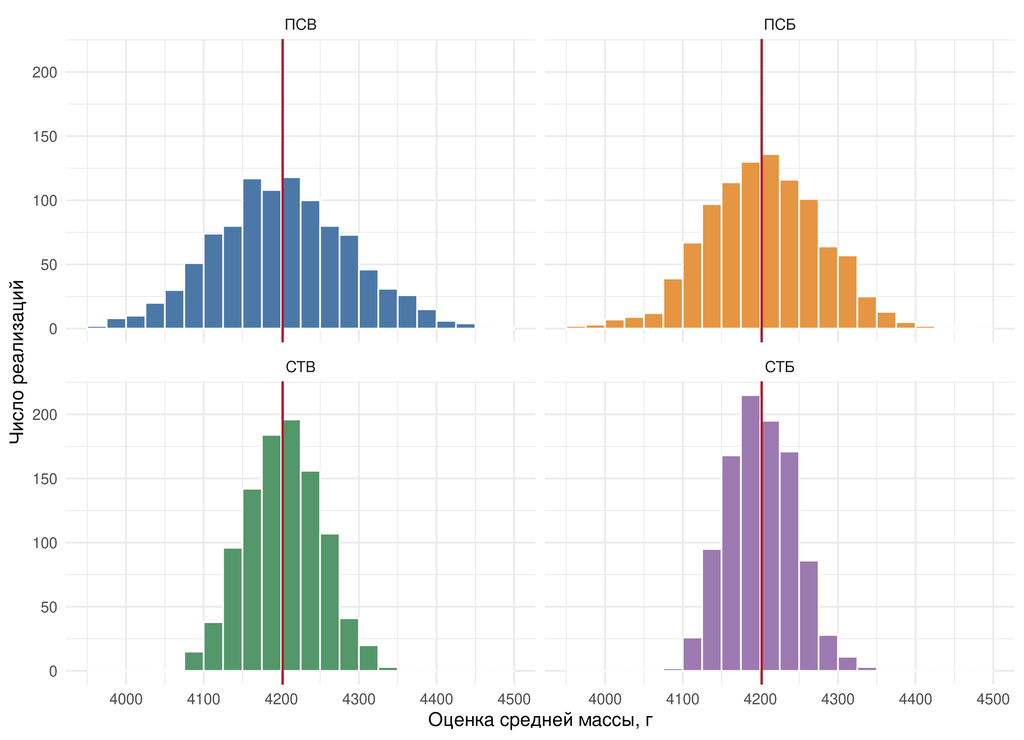

Рисунок 1. Распределения оценок средней массы.

```r
ggplot(plot_data, aes(x = Средняя, fill = Метод)) +
  geom_histogram(breaks = mass_breaks, color = "white") +
  geom_vline(xintercept = reference_mean, color = "#b2182b", linewidth = 0.7) +
  facet_wrap(~ Метод, ncol = 2) +
  scale_fill_manual(values = colors) +
  coord_cartesian(xlim = range(mass_breaks)) +
  labs(x = "Оценка средней массы, г", y = "Число реализаций") +
  theme_minimal(base_size = 12) +
  theme(legend.position = "none")
```

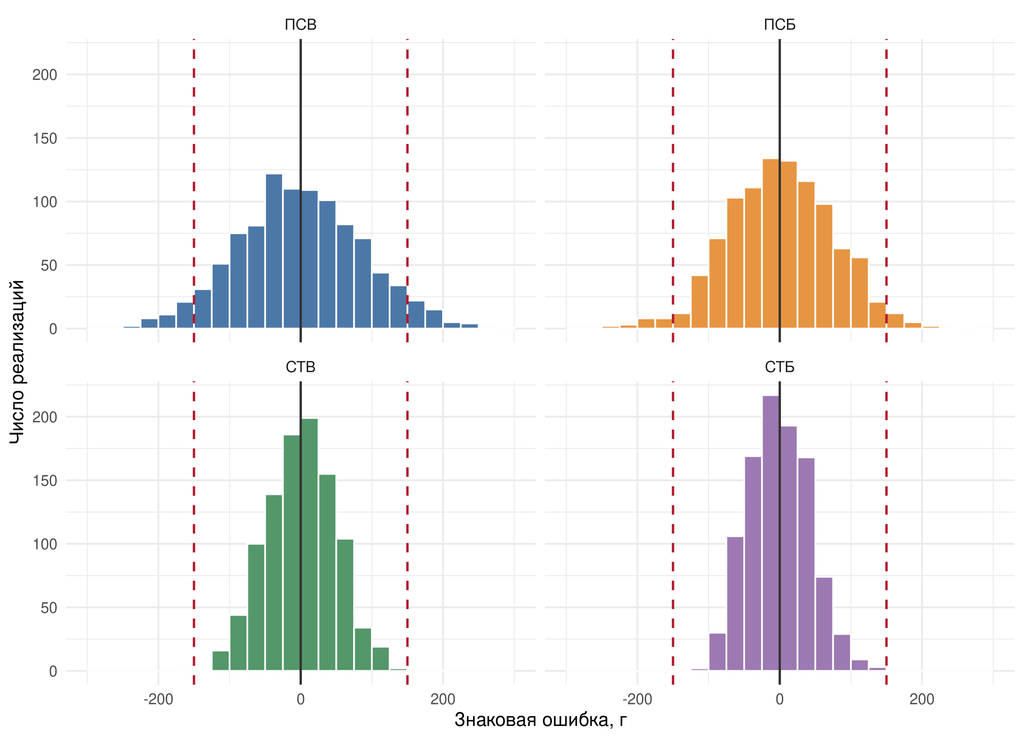

Рисунок 2. Распределения знаковых ошибок оценивания.

```r
ggplot(plot_data, aes(x = Ошибка, fill = Метод)) +
  geom_histogram(breaks = error_breaks, color = "white") +
  geom_vline(xintercept = 0, color = "#333333", linewidth = 0.7) +
  geom_vline(xintercept = c(-limit, limit), color = "#b2182b",
             linetype = "dashed", linewidth = 0.7) +
  facet_wrap(~ Метод, ncol = 2) +
  scale_fill_manual(values = colors) +
  coord_cartesian(xlim = range(error_breaks)) +
  labs(x = "Знаковая ошибка, г", y = "Число реализаций") +
  theme_minimal(base_size = 12) +
  theme(legend.position = "none")
```

## 6. Сравнение и выводы

```r
comparison <- data.frame(
  Показатель = c("Среднее из 1000 оценок, г", "Эмпирическое смещение, г",
                "Эмпирическая стандартная ошибка, г", "RMSE, г",
                "Доля оценок с абсолютной ошибкой не более 150 г"),
  metrics, check.names = FALSE
)
knitr::kable(comparison, digits = 3, row.names = FALSE)
```

| Показатель | ПСВ | ПСБ | СТВ | СТБ |
| --- | --- | --- | --- | --- |
| Среднее из 1000 оценок, г | 4201.053 | 4203.714 | 4202.265 | 4200.549 |
| Эмпирическое смещение, г | -0.701 | 1.959 | 0.511 | -1.206 |
| Эмпирическая стандартная ошибка, г | 86.827 | 73.289 | 48.456 | 42.725 |
| RMSE, г | 86.786 | 73.278 | 48.434 | 42.721 |
| Доля оценок с абсолютной ошибкой не более 150 г | 0.911 | 0.959 | 0.999 | 1.000 |

```r
minimum_se <- names(which.min(metrics["SE", ]))
maximum_share <- names(which(metrics["Доля", ] == max(metrics["Доля", ])))
```

1. **Наименьший разброс.** Минимальная стандартная ошибка у **СТБ** — **42.725 г**. Его гистограмма уже остальных при одинаковых шкалах; сравнение подтверждается рассчитанной стандартной ошибкой.
2. **Возвращение.** В проведенном эксперименте ПСБ точнее ПСВ: стандартные ошибки **73.29** и **86.83 г**. Для СТБ и СТВ получены **42.73** и **48.46 г**. Отбор без возвращения уменьшает разброс при обследовании конечной совокупности.
3. **Стратификация.** Обе стратифицированные схемы дали меньший разброс, чем соответствующие простые схемы. Средняя масса Gentoo значительно выше, чем у двух других видов. Фиксация представительства видов устраняет часть колебаний состава выборки.
4. **Допустимая ошибка.** Наибольшая доля у **СТБ** — **100%**. Для ПСБ, под который планировался объем, получено **95.9%** при ориентире 95%. Точного совпадения не требуется: разведочная дисперсия является оценкой, а 1000 повторений также дают случайные колебания. Для ПСВ та же численность не гарантирует 95%, поскольку объем учитывает бесповторный отбор. Стратификация может дополнительно повысить точность.
5. **Одна реализация.** По одной выборке надежно сравнить методы нельзя: более точный метод тоже может случайно дать большую ошибку. Поэтому сравниваем характеристики всех 1000 оценок каждого метода.

Результаты относятся к **342 записям данного набора**, а не ко всем пингвинам Антарктики. Небольшое эмпирическое смещение в таблице само по себе не означает систематического смещения метода.

Источник данных: пакет `palmerpenguins`, версия 0.1.1; [Horst, Hill, Gorman](https://github.com/allisonhorst/palmerpenguins). Условие работы: `practicum_penguins_sampling.pdf`.